# WATPY - CoRe Database Tutorial

The watpy tool is Python3 compatible. Requires basic packages like *numpy* and *matplotlib* to function properly (see README). Please install the package before trying this tutorial with

*sudo python setup.py install*

or

*python setup.py install --user*

if you do not have admin permissions. Make sure watpy has been installed at the location where your Python installation is looking for additional packages (this might differ depending on how Python has been installed on your machine).

## 0. Database Structure and Initialization

The CoRe Gravitational Wave Database is structured as follows:

Following this tutorial you should be able to syncronize the database correctly on your local machine. Note that generic users do not have write permissions on the database, so before trying to add new entries to the database please make sure to contact one of the database managers.

### 0.1 Database Index and Database Initialization

First of all, import the module containing the routines necessary for the database index operations

```python
from db_utilities.index import *
```

It is now possible to initialize an *index object*, specifying the path where we would like the CoRe database to be initialized.

```python
# This path can be an absolute or relative to the working directory
#db_path = '/path/to/CoRe_DB_dir'
db_path = '../../core_db_gitlab/'

idb = CoRe_index(db_path, lfs=True)
```

```
Index found, updating...
```

Initializing the *CoRe_index* object will clone the *core_database_index* in *db_path*, or syncronize it to the latest version in case the repository already exists.

Before syncronizing the database, it is possible to use the metadata to visualize basic population properties of the database. Here we show how to plot the database population distribution in terms of mass ratio.

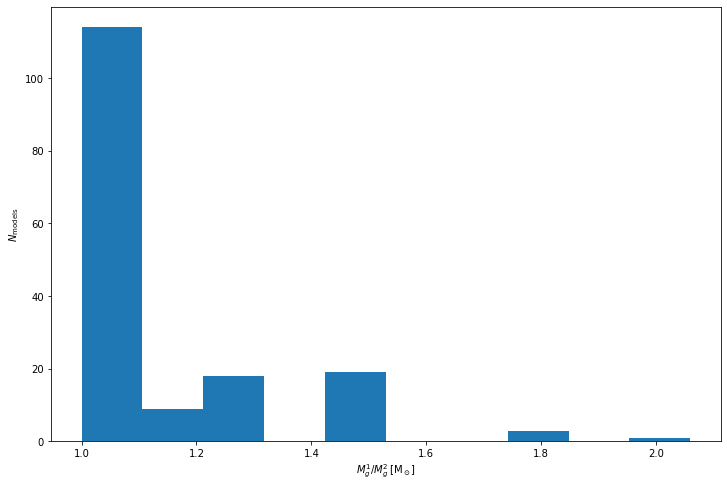

```python
idb.show('id_mass_ratio')
```

It is now possible to syncronize the entire database via the *CoRe_index* object using the following (you can forego the *verbose* argument if you would rather have some reassuring on what's happening):

```python
idb.sync_database(lfs=True, verbose=False)
```

Since the entire database is quite large, users might want to syncronize only the part of the database they intend to use. In this case, the *find(key, value)* routine of the *CoRe_index* object allows users to create a python dictionary of the simulations in the database that correspond to the indicated combination of *key* and *value* in their respective metadata dictionaries (of which the index is composed). Here we show the case of a user syncronizing only the simulations in the database whose Equation of State (EOS) is DD2. Note that the index contains only a subset of all the available metadata for each model. In particular, only *EOS*, *initial angular momentum*, *NS gravitational masses at infinity* and *initial GW frequency* are available from the index metadata.

```python
# here dd2 is a python dictionary, whose keys are the database keys of the simulations
dd2 = idb.find('id_eos', 'DD2')

# Giving the sync_database the db_list argument explicitly we enforce the syncronization/cloning only of the
# database entries whose keys are in the given list.
idb.sync_database(db_list=dd2.keys(), verbose=False, lfs=True, prot='https')
```

## 1. Database, Simulation and Run utilities

Once the database has been syncronized locally it is possible to use this tool to manage the database data and produce quick plots of its contents.

First of all, import the database utilities

```python
from db_utilities.dbutils import *
```

With the classes contained in the above module one only needs the path to where all the repositories containing data from the simulations from the CoRe GW database are situated.

First, one can recover the metadata for all available simulations with

```python
cdb = CoRe_database(db_path)
```

Once the database object is created, it is possible to manipulate the list of simulations contained in it. Due to the more populated metadata, it is also possible to visualize more database population properties (with respect to what could be done with only the database index).

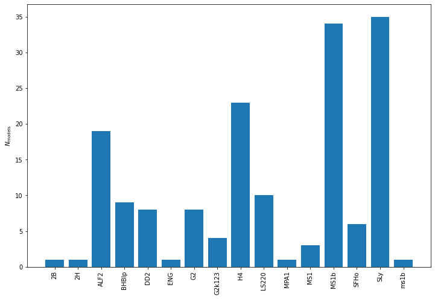

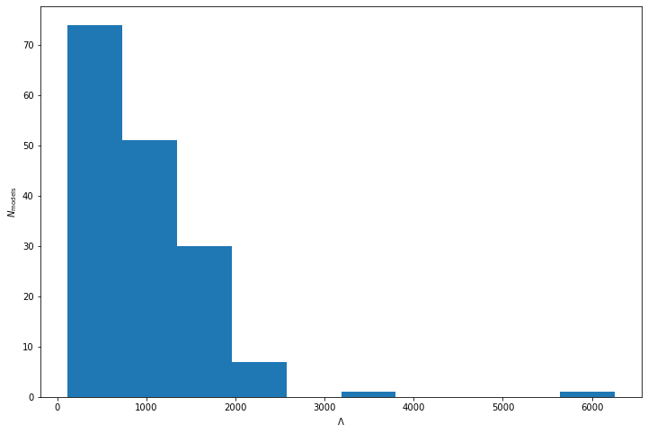

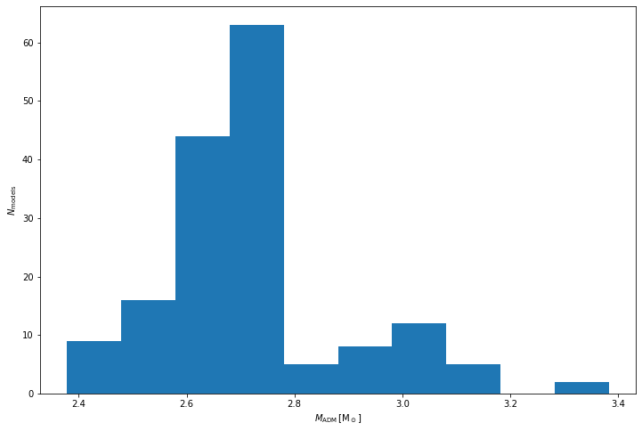

```python
cdb.show('id_eos')
cdb.show('id_Lambda')
cdb.show('id_ADM_mass')
```

This is important if one only wants to work on a subset of the entire database. The simplest manipulation is to select a subset of the database by selecting only runs that possess a certain value of a metadata keyord entry (e.g., EOS, ADM mass, ... )

```python
db_subset = cdb.find('id_eos', 'SLy')
```

```python
db_subset.keys()
```

```
dict_keys(['BAM:0100', 'BAM:0097', 'BAM:0101', 'BAM:0110', 'BAM:0120', 'BAM:0099', 'BAM:0118', 'BAM:0102', 'BAM:0115', 'BAM:0126', 'BAM:0104', 'BAM:0111', 'BAM:0123', 'THC:0036', 'BAM:0124', 'BAM:0125', 'BAM:0122', 'BAM:0109', 'BAM:0095', 'BAM:0103', 'BAM:0117', 'BAM:0112', 'BAM:0113', 'BAM:0098', '…
```

*db_subset* is now a python dictionary where the keys are the simulations' *database_keys* and the values are *Core_Simulation* objects.

```python
bam1 = cdb.sims['BAM:0001']
```

The *CoRe_simulation* object contains all information on the number of runs available for that set of initial data, as well as the required routines to extract the data from the HDF5 archive into readable text files that can be easily loaded into python for plots and/or further analysis.

```python
print(bam1.runs_id)

r01 = bam1.runs['R01']
```

```
['R04', 'R01', 'R03', 'R02']
```

Once we select the desired run, we can extract data via the h5 sub-class. We can choose what to extract ($h$, $\Psi_4$ or the energetics of the waveform) or just extract everything in the same directory where the original HDF5 archive was stored.

**PLEASE NOTE THAT THE EXTRACTED FILES ARE NOT TRACKED BY THE REPOSITORY, AND SHOULD NOT BE ADDED TO ANY COMMIT. ONLY THE HDF5 ARCHIVE SHOULD BE PUSHED TO THE REPOSITORY AFTER A SIGNIFICANT (AND APPROVED) CHANGE**

```python
r01.h5.extract_all()
```

It is now possible to easily load the .txt files via usual python means (numpy.loadtxt or analogous modules). Another option is to use the *extract_h()* (or *extract_p4()*, *extract_ej()* for the other data) with the "return" keyword set to "True".

Watpy also has routines to only read the data at the chosen extraction radius. If no radius is given, or if the selected radius is not within the available ones, the farthest radius from the center of the simulation domain is chosen by default.

```python
u, h = r01.h5.read('rh_22')
```

In this case we return the time as the tortoise coordinate $u$ and the complex-valued strain $h$ for the $l=m=2$ mode.

There are also built-in routines to make quick visualization of the waveforms, allowing the user to quickly visualize both the strain and the Weyl scalar. It is also possible to only show one of the two variables by selecting it as for the *.read()* method. Note that also for the *.show()* method it is possible to give a specific extraction radius (again, the default is to plot the farthest).

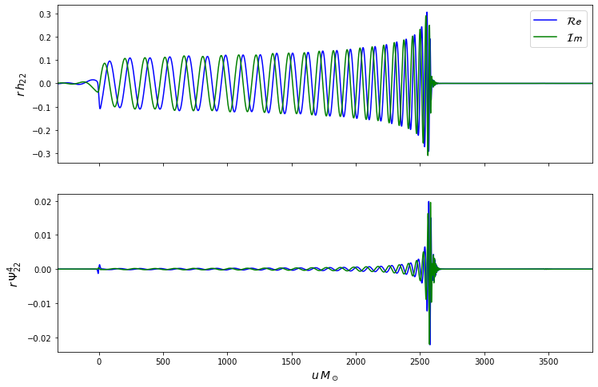

```python
r01.h5.show('both')
```

## 2. New database entry setup

*Classes from base/wave.py and db_utilities/db_utils.py*

Watpy contains routines to create appropriately formatted data for adding a new entry to the CoRe Database. At the moment both WhiskyTHC and BAM simulations can be processed automatically, after following a specific procedure (described below). Please make sure the data is indeed in the correct format, and that metadata files have been correctly compiled/updated before pushing changes to an existing repository (or creating a new repository if the model was not already present in the database).

The first steps are in common for both codes.

- Setup new folder with the correct directory tree. You will be notified whether the new run has been added to an existing entry or if a new one has been created. The routine returns the *database_key* of the new/updated entry

```python
new_dbkey = cdb.setup_new_run('THC_fake_test_run', 'THC')
#rep_dbkey = cdb.setup_new_run('MS1b_1.375_1.375_0.11_0.00_0.0348_0.167', 'BAM')
```

```
Created new database entry THC:0037.
```

- In either case, we now need to fill the metadata appropriately. If a new entry has been created, a new *metadata_main.txt* and *metadata.txt* must be created. If the run has been added to an existing entry, the *available_resolutions* key of *metadata_main.txt* will be updated and a new *metadata.txt* for the new run will be created.

```python
# First, we create a simulation object. Note that if the entry was already existing, we can take this from cdb.sims
new_sim = CoRe_simulation(os.path.join(cdb.path,new_dbkey.replace(':','_')))
#rep_sim = CoRe_simulation(rep_dbkey.replace(':','_'))

# Now we must create the metadata for the last added run (for a new entry this is just R01)
# We can also look at which keys are required by calling mdu.keys
print(mdu.keys)

mdata_n = {}
mdata_r = {}

for key in mdu.keys:
    mdata_n[key] = None
    mdata_r[key] = None
#

# All keys should be filled, but at least simulation name one has to be added before creating the metadata
# This is due to how the database looks for existing simulations (see above)

mdata_n['simulation_name'] = 'THC_fake_test_run'
mdata_r['simulation_name'] = 'MS1b_1.375_1.375_0.11_0.00_0.0348_0.167'

# Other information should be added now, but can in principle be also added later on by manipulating the dictionary

mdata_n['id_eos'] = 'BLh'
mdata_r['evolution_code'] = 'bam_14.07'
```

```
Empty database entry!
No .h5 file found!
['database_key', 'simulation_name', 'available_resolutions', 'reference_bibkeys', 'id_code', 'id_type', 'id_mass', 'id_rest_mass', 'id_mass_ratio', 'id_ADM_mass', 'id_ADM_angularmomentum', 'id_gw_frequency_Hz', 'id_gw_frequency_Momega22', 'id_eos', 'id_kappa2T', 'id_Lambda', 'id_mass_starA', 'id_res…
```

- Now we split the cases: if the entry is a new one, we need to create a *metadata_main.txt* file in the database entry directory

```python
md_s = new_sim.create_metadata(mdata_n)
#md_r = new_sim.runs['R01'].create_metadata(mdata_n)
```

```
Working on database model...
No .h5 file found!
No .h5 file found!
```

- Otherwise, we just add the new resolution to the existing metadata by getting them again and updating

```python
md = rep_sim.get_metadata()
# We add the new resolution run to the available_resolutions key
md['available_resolutions'] += ', R03'
rep_sim.update_metadata(md)

# Then we create the metadata for the new run
rep_sim.runs['R03'].create_metadata()
```

Now that we are set up, different codes have a slightly different procedure to follow